# Public and economic effects of storms and other severe weather events in USA

Aanjaneya Mishra

16/02/2015

## Synopsis

In this report we explore the U.S. National Oceanic and Atmospheric Administration’s (NOAA) storm database. This database tracks characteristics of major storms and weather events in the United States, including when and where they occur, as well as estimates of any fatalities, injuries, and property damage. In this report we are tasked with answering the following questions:

1. Across the United States, which types of events (as indicated in the EVTYPE variable) are most harmful with respect to population health?
2. Across the United States, which types of events have the greatest economic consequences?

Upon exploring the storm database we found that Tornadoes are most harmful with respect to population health followed by Excessive Heat, Flash Flood, Heat. Lightning etc. We also found that Flood was the most harmful for properties followed by Hurricane/Typhoon, Tornado, Storm Surge etc. In case of crop damage Drought was the most harmful followed by Flood, River Flood, Ice Storm, Hail etc.

## Data Processing

From the URL https://d396qusza40orc.cloudfront.net/repdata%2Fdata%2FStormData.csv.bz2 we obtained U.S. National Oceanic and Atmospheric Administration’s (NOAA) data on major storms and weather events in the United States from the year 1950 to November 2011. In the data processing step we will get the storm data and then process it to a form suitable for determining the required results.

### Downloading the data

```r
if(!file.exists("repdata_data_StormData.csv.bz2")) {
fileURL <- "https://d396qusza40orc.cloudfront.net/repdata%2Fdata%2FStormData.csv.bz2"
download.file(fileURL, destfile="repdata_data_StormData.csv.bz2", method = "curl")
}
```

### Reading The data

```r
stormdata <- read.csv(bzfile("repdata_data_StormData.csv.bz2"))
```

### Data summary

```r
dim(stormdata)
```

```
## [1] 902297     37
```

```r
str(stormdata)
```

```
## 'data.frame':    902297 obs. of  37 variables:
##  $ STATE__   : num  1 1 1 1 1 1 1 1 1 1 ...
##  $ BGN_DATE  : Factor w/ 16335 levels "10/10/1954 0:00:00",..: 6523 6523 4213 11116 1426 1426 1462 2873 3980 3980 ...
##  $ BGN_TIME  : Factor w/ 3608 levels "000","0000","00:00:00 AM",..: 212 257 2645 1563 2524 3126 122 1563 3126 3126 ...
##  $ TIME_ZONE : Factor w/ 22 levels "ADT","AKS","AST",..: 7 7 7 7 7 7 7 7 7 7 ...
##  $ COUNTY    : num  97 3 57 89 43 77 9 123 125 57 ...
##  $ COUNTYNAME: Factor w/ 29601 levels "","5NM E OF MACKINAC BRIDGE TO PRESQUE ISLE LT MI",..: 13513 1873 4598 10592 4372 10094 1973 23873 24418 4598 ...
##  $ STATE     : Factor w/ 72 levels "AK","AL","AM",..: 2 2 2 2 2 2 2 2 2 2 ...
##  $ EVTYPE    : Factor w/ 985 levels "?","ABNORMALLY DRY",..: 830 830 830 830 830 830 830 830 830 830 ...
##  $ BGN_RANGE : num  0 0 0 0 0 0 0 0 0 0 ...
##  $ BGN_AZI   : Factor w/ 35 levels "","E","Eas","EE",..: 1 1 1 1 1 1 1 1 1 1 ...
##  $ BGN_LOCATI: Factor w/ 54429 levels "","?","(01R)AFB GNRY RNG AL",..: 1 1 1 1 1 1 1 1 1 1 ...
##  $ END_DATE  : Factor w/ 6663 levels "","10/10/1993 0:00:00",..: 1 1 1 1 1 1 1 1 1 1 ...
##  $ END_TIME  : Factor w/ 3647 levels "","?","0000",..: 1 1 1 1 1 1 1 1 1 1 ...
##  $ COUNTY_END: num  0 0 0 0 0 0 0 0 0 0 ...
```

[output cut: 23 more lines]

### Processing the data for the purpose of getting results

#### Effect of storms and severe weather on health of population accross USA

To be able to determine this aspect in the results section we will use the FATALITIES and INJURIES columns of the storm data as these columns are relevant for determination of effect on public health.

Aggregate and order fatalities by event type

```r
fatalities <- aggregate(FATALITIES ~ EVTYPE, stormdata, sum)
colnames(fatalities) <- c("Event", "Fatalaties")
fatalities <- fatalities[order(fatalities$Event), ]
```

Aggregate and order injuries by event type

```r
injuries <- aggregate(INJURIES ~ EVTYPE, stormdata, sum)
colnames(injuries) <- c("Event", "Injuries")
injuries <- injuries[order(injuries$Event), ]
```

Combine fatalities and injuries by event type.

```r
healthimpact <- cbind(fatalities, injuries$Injuries)
colnames(healthimpact) <- c("Event", "Fatalaties", "Injuries")
```

Clean and narrow down healthimpact table by removing values where fatalities and injuries are 0. We do this since events with 0 occurrences are not useful for determination of meaningful results.

```r
healthimpact <-healthimpact[healthimpact$Fatalaties > 0 | healthimpact$Injuries > 0, ]
rownames(healthimpact) <- NULL
head(healthimpact)
```

```
##          Event Fatalaties Injuries
## 1     AVALANCE          1        0
## 2    AVALANCHE        224      170
## 3    BLACK ICE          1       24
## 4     BLIZZARD        101      805
## 5 blowing snow          1        1
## 6 BLOWING SNOW          1       13
```

We order the healthimpact table to put the events in decreasing order of effect on population health. In other words decreasing ordering will put most harmful events at the top of the table while those least harmful at the bottom.

```r
healthimpact <- healthimpact[order(healthimpact$Fatalaties, healthimpact$Injuries, decreasing = TRUE), ]
head(healthimpact)
```

```
##              Event Fatalaties Injuries
## 184        TORNADO       5633    91346
## 32  EXCESSIVE HEAT       1903     6525
## 42     FLASH FLOOD        978     1777
## 69            HEAT        937     2100
## 122      LIGHTNING        816     5230
## 191      TSTM WIND        504     6957
```

#### Economic effects of storms and severe weather accross USA

To be able to determine this aspect in the results section we will use the PROPDMG, PROPDMGEXP, CROPDMG and CROPDMGEXP columns of the storm data as these columns are relevant for determination economic consequences. The columns PROPDMG and CROPDMG contain units of damage whereas the PROPDMGEXP and CROPDMGEXP contain exponentials(10^x) like million or billion to be applied to PROPDMG and CROPDMG. Therefore, in order to get the true value of property and crop damage we need to interpret, recode the PROPDMGEXP and CROPDMGEXP variables and then merge them with PROPDMG and CROPDMG.

Interpret and recode the PROPDMGEXP and CROPDMGEXP values to numeric versions so that we can apply arithmetic calculations to it.

```r
library(car)
stormdata$PROPDMGEXP <- factor(tolower(stormdata$PROPDMGEXP))
stormdata$PROPDMGEXP <- as.numeric(recode(as.character(stormdata$PROPDMGEXP), "'0'=1;'1'=10;'2'=10^2;'3'=10^3;'4'=10^4;'5'=10^5;'6'=10^6;'7'=10^7;'8'=10^8;'b'=10^9;'h'=10^2;'k'=10^3;'m'=10^6;'-'=0;'?'=0;'+'=0"))

stormdata$CROPDMGEXP <- factor(tolower(stormdata$CROPDMGEXP))
stormdata$CROPDMGEXP <- as.numeric(recode(as.character(stormdata$CROPDMGEXP), "'0'=1;'1'=10;'2'=10^2;'3'=10^3;'4'=10^4;'5'=10^5;'6'=10^6;'7'=10^7;'8'=10^8;'b'=10^9;'h'=10^2;'k'=10^3;'m'=10^6;'-'=0;'?'=0;'+'=0"))
```

Apply the recoded numeric values of PROPDMGEXP and CROPDMGEXP to PROPDMG and CROPDMG to calculate the actual crop and property damages. It will be done by multiplying PROPDMGEXP with PROPDMG and CROPDMGEXP with CROPDMG.

```r
stormdata$PROPDMGVALUE <- stormdata$PROPDMG * stormdata$PROPDMGEXP
stormdata$CROPDMGVALUE <- stormdata$CROPDMG * stormdata$CROPDMGEXP
```

Aggregate and order property damage by event type

```r
propdamage <- aggregate(PROPDMGVALUE ~ EVTYPE, stormdata, sum)
colnames(propdamage) <- c("Event", "PropertyDamage")
propdamage <- propdamage[order(propdamage$Event), ]
```

Aggregate and order crop damage by event type

```r
cropdamage <- aggregate(CROPDMGVALUE ~ EVTYPE, stormdata, sum)
colnames(cropdamage) <- c("Event", "CropDamage")
cropdamage <- cropdamage[order(cropdamage$Event), ]
```

Clean and narrow down propdamage and cropdamage tables by removing values where propertydamage and cropdamage are 0. We do this since events with 0 occurrences are not useful for determination of meaningful results.

```r
propimpact <- propdamage[propdamage$PropertyDamage > 0, ]
head(propimpact)
```

```
##                    Event PropertyDamage
## 1                      ?           5000
## 2          APACHE COUNTY           5000
## 3 ASTRONOMICAL HIGH TIDE        9425000
## 4  ASTRONOMICAL LOW TIDE         320000
## 5              AVALANCHE        3721800
## 6          Beach Erosion         100000
```

```r
cropimpact <- cropdamage[cropdamage$CropDamage > 0, ]
head(cropimpact)
```

```
##                      Event CropDamage
## 1      AGRICULTURAL FREEZE   28820000
## 5                 BLIZZARD  112060000
## 7         COASTAL FLOODING      56000
## 8         COLD AIR TORNADO         50
## 9  COLD AND WET CONDITIONS   66000000
## 10         COLD/WIND CHILL     600000
```

We order the propimpact and cropimpact tables to put the events in decreasing order of economic effect. In other words decreasing ordering will put most economically harmful events at the top of the table while those least harmful at the bottom.

```r
propimpact <- propimpact[order(propimpact$PropertyDamage, decreasing = TRUE), ]
head(propimpact)
```

```
##                 Event PropertyDamage
## 60              FLOOD   144657709800
## 179 HURRICANE/TYPHOON    69305840000
## 333           TORNADO    56947380614
## 281       STORM SURGE    43323536000
## 48        FLASH FLOOD    16822673772
## 102              HAIL    15735267456
```

```r
cropimpact <- cropimpact[order(cropimpact$CropDamage, decreasing = TRUE), ]
head(cropimpact)
```

```
##          Event  CropDamage
## 16     DROUGHT 13972566000
## 35       FLOOD  5661968450
## 99 RIVER FLOOD  5029459000
## 86   ICE STORM  5022113500
## 53        HAIL  3025954470
## 78   HURRICANE  2741910000
```

## Results

### Across the United States, which types of events (as indicated in the EVTYPE variable) are most harmful with respect to population health?

To answer this question we will draw a stacked barplot to see the fatalities and injuries related to different most devastating weather events. The stacked barplot shows relative differences between numbers of fatalities and injuries caused by most harmful events. We will also see the numbers (numeric view )of fatalities and injuries for top 6 events.

Numeric view of fatalities and injuries for top 6 events are as follows. We can see that Tornadoes are most harmful with respect to population health. Tornadoes are followed by Excessive Heat, Flash Flood, Heat. Lightning etc.

```r
head(healthimpact)
```

```
##              Event Fatalaties Injuries
## 184        TORNADO       5633    91346
## 32  EXCESSIVE HEAT       1903     6525
## 42     FLASH FLOOD        978     1777
## 69            HEAT        937     2100
## 122      LIGHTNING        816     5230
## 191      TSTM WIND        504     6957
```

To draw the barplot we need to convert heathimpact table calculated above into matrix and transpose it.

```r
plotdatahealth <- as.matrix(healthimpact[, c("Fatalaties", "Injuries")])
rownames(plotdatahealth) <- healthimpact$Event
tplotdatahealth <- t(plotdatahealth)
```

Now the bar plot for effect on health of population. The barplot shows effect on health by means of stacked plot of numbers of fatalities and injuries by event types.

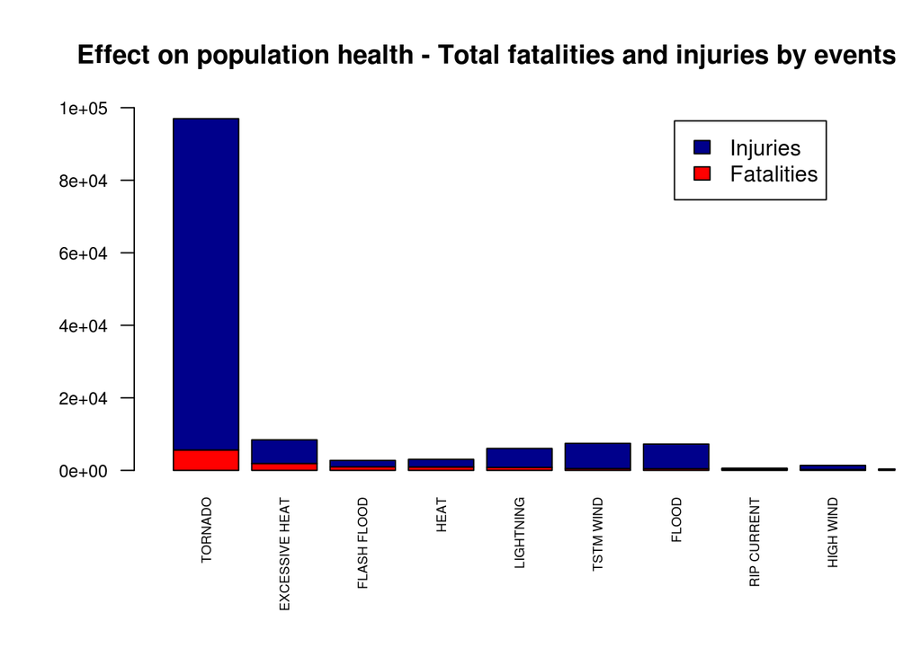

```r
par(oma = c(2, 1, 0, 1))
barplot(tplotdatahealth, names.arg = healthimpact$Event, legend = c( "Fatalities", "Injuries"),
    main = "Effect on population health - Total fatalities and injuries by events", col = c("red", "darkblue"), xlim = c(0,10), ylim = c(0,100000), cex.axis = 0.8, cex.names = 0.6, las = 2)
```

### Across the United States, which types of events have the greatest economic consequences?

To answer this question we will draw two barplots(one for crop damage and the other for property damage) to see economic consequences of most devastating weather events. We will also see the numbers (numeric view )of property and crop damages for top 6 events.

Numeric view of property and crop damages for top 6 events are as follows. We can see that in case of property damage Flood was the most harmful followed by Hurricane/Typhoon, Tornado, Storm Surge etc. In case of crop damage Drought was the most harmful followed by Flood, River Flood, Ice Storm, Hail etc

```r
head(propimpact)
```

```
##                 Event PropertyDamage
## 60              FLOOD   144657709800
## 179 HURRICANE/TYPHOON    69305840000
## 333           TORNADO    56947380614
## 281       STORM SURGE    43323536000
## 48        FLASH FLOOD    16822673772
## 102              HAIL    15735267456
```

```r
head(cropimpact)
```

```
##          Event  CropDamage
## 16     DROUGHT 13972566000
## 35       FLOOD  5661968450
## 99 RIVER FLOOD  5029459000
## 86   ICE STORM  5022113500
## 53        HAIL  3025954470
## 78   HURRICANE  2741910000
```

Barplots for property and crop damage. These barplots clearly show the economic consequences by means of separate plots for crop and property damages.

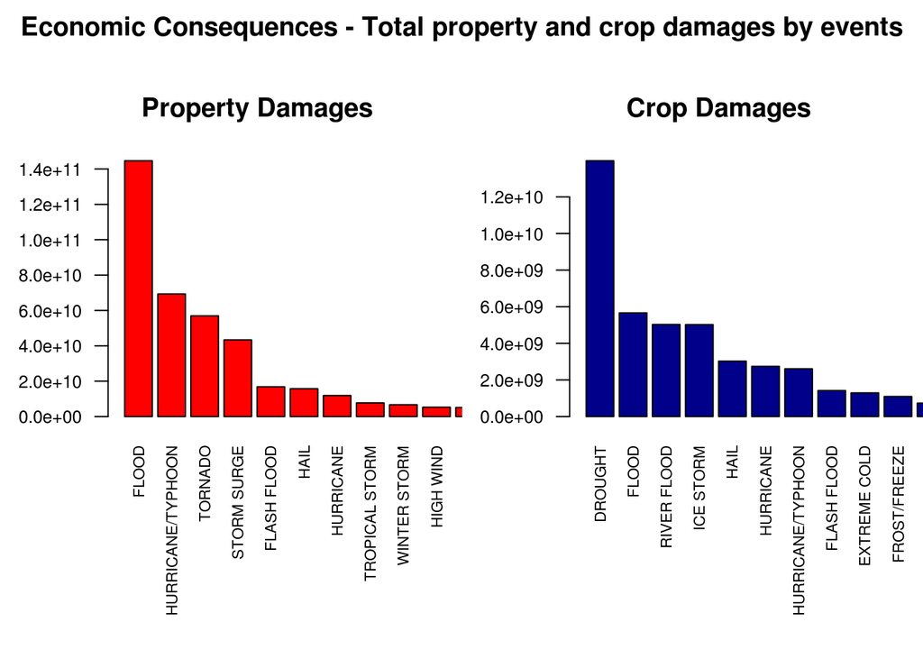

```r
par(mfrow = c(1, 2), oma = c(4, 0, 2, 0))
barplot(propimpact$PropertyDamage, names.arg = propimpact$Event, main = "Property Damages",
    cex.axis = 0.8, cex.names = 0.7, las = 2, col = "red", xlim = c(0,10))
barplot(cropimpact$CropDamage, names.arg = cropimpact$Event, main = "Crop Damages",
    cex.axis = 0.8, cex.names = 0.7, las = 2, col = "darkblue", xlim = c(0,10))
title("Economic Consequences - Total property and crop damages by events", outer = TRUE)
```